# Econométrie Spatiale - Application sur le taux de criminalité

Author

Isabelle Cadoret

Téléchargement des packages

```r
pacman::p_load(dplyr,stargazer,RColorBrewer,ggridges,tidyr,spatialreg, ggplot2,spdep, sf,readr,readxl,lmtest,tmap,stringr,viridis, vtable, knitr )
```

## 1 Lecture des données et matrice de contiguité

### 1.1 Lecture des données

- Source :

https://geodacenter.github.io/data-and-lab/

https://geodacenter.github.io/data-and-lab/columbus-template/

- Intitulé des séries

  HOVAL : housing value (in 1,000 USD)

  INC : household income (in 1,000 USD)

  CRIME : residential burglaries and vehicle thefts per thousand households in the neighborhood

```r
columbus<- st_read(dsn="columbus.shp",layer="columbus")
```

### 1.2 Matrice de poids spatiale basée sur la contiguité

Contruction de la matrice de contiguité

- Identification des voisins avec la fonction **poly2nb** et représentation des liens

```r
mapC.nb<-poly2nb(columbus,queen = TRUE)
```

- création de la matrice de poids standardisée avec la fonction **nb2listw**

```r
col.listw<-nb2listw(mapC.nb,style="W")
```

## 2 Estimation avec les MCO et tests sur les résidus

### 2.1 Estimation de l’équation avec les MCO

```r
CRIME_OLS = lm(CRIME~INC+HOVAL, data=columbus)
summary(CRIME_OLS)
```

```
Call:
lm(formula = CRIME ~ INC + HOVAL, data = columbus)

Residuals:
    Min      1Q  Median      3Q     Max
-34.418  -6.388  -1.580   9.052  28.649

Coefficients:
            Estimate Std. Error t value Pr(>|t|)
(Intercept)  68.6190     4.7355  14.490  < 2e-16 ***
INC          -1.5973     0.3341  -4.780 1.83e-05 ***
HOVAL        -0.2739     0.1032  -2.654   0.0109 *
---
Signif. codes:  0 '***' 0.001 '**' 0.01 '*' 0.05 '.' 0.1 ' ' 1

Residual standard error: 11.43 on 46 degrees of freedom
Multiple R-squared:  0.5524,    Adjusted R-squared:  0.5329
F-statistic: 28.39 on 2 and 46 DF,  p-value: 9.341e-09
```

```r
bptest(CRIME_OLS)
```

```
    studentized Breusch-Pagan test

data:  CRIME_OLS
BP = 7.2166, df = 2, p-value = 0.0271
```

### 2.3 Test de Moran d’autocorrélation spatiale

La fonction **moran.test** sur les résidus n’est pas adaptée ici car elle ne prend pas en compte que le résidus est le résultat d’une estimation MCO

```r
morantest_Res<- moran.test(CRIME_OLS$residuals,col.listw,randomisation=FALSE,alternative="two.sided")
morantest_Res
```

```
    Moran I test under normality

data:  CRIME_OLS$residuals
weights: col.listw

Moran I statistic standard deviate = 2.6253, p-value = 0.008657
alternative hypothesis: two.sided
sample estimates:
Moran I statistic       Expectation          Variance
      0.222109407      -0.020833333       0.008563413
```

Il faut utiliser la fonction **lm.morantest** qui permet de calculer la bonne espérance et la bonne variance.

```r
Moran_Res=lm.morantest(CRIME_OLS,col.listw, alternative="two.sided")
Moran_Res
```

```
    Global Moran I for regression residuals

data:
model: lm(formula = CRIME ~ INC + HOVAL, data = columbus)
weights: col.listw

Moran I statistic standard deviate = 2.8393, p-value = 0.004521
alternative hypothesis: two.sided
sample estimates:
Observed Moran I      Expectation         Variance
     0.222109407     -0.033418335      0.008099305
```

## 3 Estimation du modèle SLX

### 3.1 Estimation MCO avec la fonction lm

- Spatial lag des variables INC et HOVAL

```r
columbus$W_INC <- lag.listw(col.listw, columbus$INC)
columbus$W_HOVAL <- lag.listw(col.listw, columbus$HOVAL)
```

- Estimation avec la fonction **LM**

```r
CRIME_SLX = lm(CRIME~INC+HOVAL+W_INC+W_HOVAL, data=columbus)
summary(CRIME_SLX)
```

```
Call:
lm(formula = CRIME ~ INC + HOVAL + W_INC + W_HOVAL, data = columbus)

Residuals:
    Min      1Q  Median      3Q     Max
-36.342  -7.662  -0.013   7.978  25.572

Coefficients:
            Estimate Std. Error t value Pr(>|t|)
(Intercept)  74.5534     6.7156  11.101 2.42e-14 ***
INC          -1.0974     0.3738  -2.936  0.00528 **
HOVAL        -0.2944     0.1017  -2.896  0.00587 **
W_INC        -1.3987     0.5601  -2.497  0.01633 *
W_HOVAL       0.2148     0.2079   1.033  0.30712
---
Signif. codes:  0 '***' 0.001 '**' 0.01 '*' 0.05 '.' 0.1 ' ' 1

Residual standard error: 10.91 on 44 degrees of freedom
Multiple R-squared:  0.6105,    Adjusted R-squared:  0.5751
F-statistic: 17.24 on 4 and 44 DF,  p-value: 1.413e-08
```

### 3.2 Estimation MCO avec la fonction **lmSLX**

```r
CRIME_SLX = lmSLX(CRIME ~ INC + HOVAL, data=columbus,col.listw)
summary(CRIME_SLX)
```

```
Call:
lm(formula = formula(paste("y ~ ", paste(colnames(x)[-1], collapse = "+"))),
    data = as.data.frame(x), weights = weights)

Coefficients:
             Estimate    Std. Error  t value     Pr(>|t|)
(Intercept)   7.455e+01   6.716e+00   1.110e+01   2.416e-14
INC          -1.097e+00   3.738e-01  -2.936e+00   5.277e-03
HOVAL        -2.944e-01   1.017e-01  -2.896e+00   5.868e-03
lag.INC      -1.399e+00   5.601e-01  -2.497e+00   1.633e-02
lag.HOVAL     2.148e-01   2.079e-01   1.033e+00   3.071e-01
```

### 3.3 Calcul des effets marginaux avec la fonction **impacts**

```r
set.seed(132)
impacts(CRIME_SLX,listw=col.listw)
```

```
Impact measures (SlX, glht):
                Direct  Indirect       Total
INC dy/dx   -1.0973898 -1.398746 -2.49613551
HOVAL dy/dx -0.2943898  0.214841 -0.07954881
```

```r
summary(impacts(CRIME_SLX,listw=col.listw), zstats=TRUE)
```

```
Impact measures (SlX, glht, n-k):
                Direct  Indirect       Total
INC dy/dx   -1.0973898 -1.398746 -2.49613551
HOVAL dy/dx -0.2943898  0.214841 -0.07954881
========================================================
Standard errors:
               Direct  Indirect     Total
INC dy/dx   0.3738313 0.5601247 0.4929713
HOVAL dy/dx 0.1016586 0.2079212 0.2074767
========================================================
Z-values:
               Direct  Indirect      Total
INC dy/dx   -2.935522 -2.497204 -5.0634496
HOVAL dy/dx -2.895867  1.033281 -0.3834108

p-values:
            Direct    Indirect Total
INC dy/dx   0.0033299 0.012518 4.1174e-07
HOVAL dy/dx 0.0037811 0.301473 0.70142
```

### 3.4 Analyse des résidus

- Test d’autocorrélation spatiale sur les résidus

```r
Moran_Res_SLX=lm.morantest(CRIME_SLX,col.listw, alternative="two.sided")
Moran_Res_SLX
```

```
    Global Moran I for regression residuals

data:
model: lm(formula = formula(paste("y ~ ", paste(colnames(x)[-1],
collapse = "+"))), data = as.data.frame(x), weights = weights)
weights: col.listw

Moran I statistic standard deviate = 2.747, p-value = 0.006015
alternative hypothesis: two.sided
sample estimates:
Observed Moran I      Expectation         Variance
     0.205464105     -0.042812387      0.008168872
```

- Représentation cartographique des résidus

a) Résidus du modèle sans autocorrélation spatiale

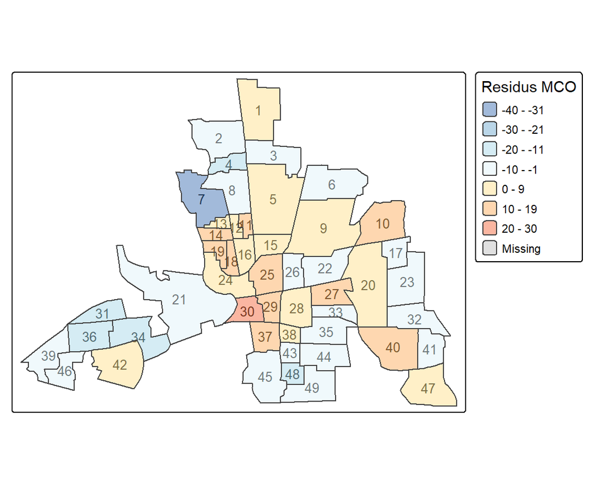

```r
columbus$ols_res<-resid(CRIME_OLS)

tm_shape(columbus) +tm_text(text = "POLYID",size=0.8)+
  tm_polygons("ols_res", alpha=0.5,palette="-RdYlBu",
              style="pretty", id="POLYID",
              title="Residus MCO")
```

b) Résidus du modèle SLX

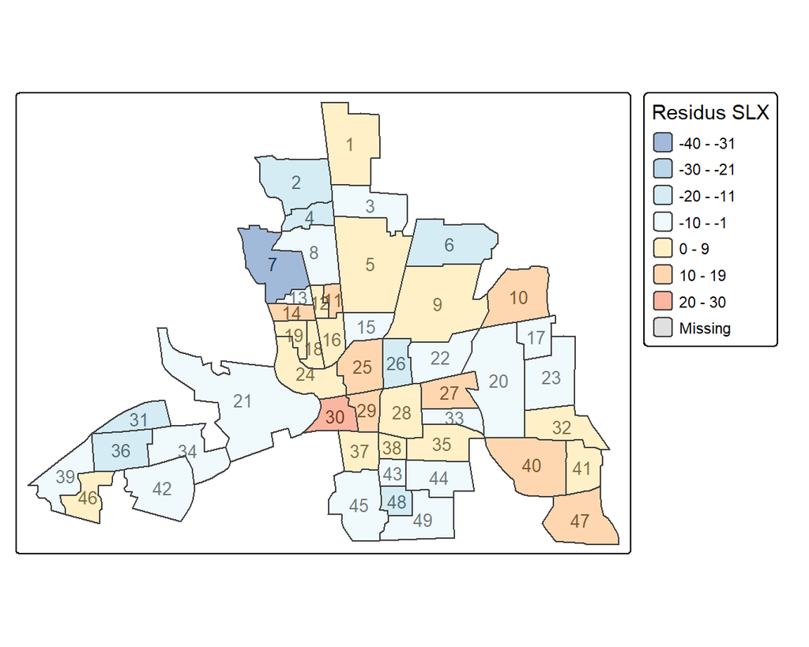

```r
columbus$slx_res<-resid(CRIME_SLX)
tm_shape(columbus) +tm_text(text = "POLYID",size=0.8)+
  tm_polygons("slx_res", alpha=0.5,palette="-RdYlBu",
              style="pretty", id="POLYID",
              title="Residus SLX")
```

- Représentation de la densité des résidus MCO et SLX

Les résidus SLX semblent un peu mieux centrés autour de 0

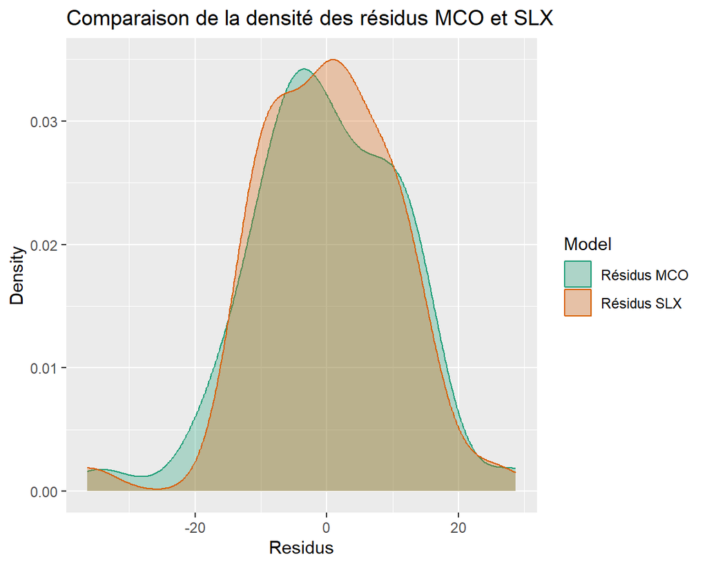

```r
columbus%>%st_drop_geometry() %>%
  pivot_longer(cols = c('ols_res','slx_res')) %>%
  ggplot() +
    geom_density(mapping = aes(x = value,
                          color = name, fill = name),
            alpha = 0.3) +#stop code here first time to know the order of the labels
    scale_color_manual(values=brewer.pal(n = 3, name = "Dark2"),labels=c("Résidus MCO","Résidus SLX"))+
    scale_fill_manual(values=brewer.pal(n = 3, name = "Dark2"),labels=c("Résidus MCO","Résidus SLX")) +
    labs(x = "Residus", y = "Density",
       title = "Comparaison de la densité des résidus MCO et SLX",
       color = "Model",
       fill = "Model")
```

## 4 Estimation du modèle SAR

### 4.1 Estimateur du maximum de vraissemblance SAR

Il ne faut pas utiliser l’estimateur MCO, l’estimateur est biaisé et non convergent

```r
W_CRIME<- lag.listw(col.listw,columbus$CRIME)
CRIME_SAR_OLS<-lm(CRIME~W_CRIME+INC+HOVAL,data=columbus)
summary(CRIME_SAR_OLS)
```

```
Call:
lm(formula = CRIME ~ W_CRIME + INC + HOVAL, data = columbus)

Residuals:
    Min      1Q  Median      3Q     Max
-38.610  -6.198   0.188   6.810  21.718

Coefficients:
            Estimate Std. Error t value Pr(>|t|)
(Intercept) 38.78334    9.32251   4.160 0.000141 ***
W_CRIME      0.54876    0.15288   3.589 0.000815 ***
INC         -0.88617    0.35773  -2.477 0.017064 *
HOVAL       -0.26408    0.09204  -2.869 0.006245 **
---
Signif. codes:  0 '***' 0.001 '**' 0.01 '*' 0.05 '.' 0.1 ' ' 1

Residual standard error: 10.19 on 45 degrees of freedom
Multiple R-squared:  0.652, Adjusted R-squared:  0.6288
F-statistic: 28.11 on 3 and 45 DF,  p-value: 2.149e-10
```

Il faut utiliser la fonction **lagsarlm qui applique le Maximum de vraissemblance**

```r
CRIME_SAR <- lagsarlm(CRIME~INC+HOVAL, listw=col.listw,  data=columbus)
summary(CRIME_SAR)
```

```
Call:
lagsarlm(formula = CRIME ~ INC + HOVAL, data = columbus, listw = col.listw)

Residuals:
       Min         1Q     Median         3Q        Max
-37.652017  -5.334611   0.071473   6.107196  23.302617

Type: lag
Coefficients: (asymptotic standard errors)
             Estimate Std. Error z value  Pr(>|z|)
(Intercept) 45.603248   7.257404  6.2837 3.306e-10
INC         -1.048728   0.307406 -3.4115  0.000646
HOVAL       -0.266335   0.089096 -2.9893  0.002796

Rho: 0.42333, LR test value: 9.4065, p-value: 0.0021621
Asymptotic standard error: 0.11951
    z-value: 3.5422, p-value: 0.00039686
Wald statistic: 12.547, p-value: 0.00039686

Log likelihood: -182.674 for lag model
ML residual variance (sigma squared): 96.857, (sigma: 9.8416)
Number of observations: 49
Number of parameters estimated: 5
AIC: 375.35, (AIC for lm: 382.75)
LM test for residual autocorrelation
test value: 0.24703, p-value: 0.61917
```

### 4.2 Calcul des effets directs et indirects avec la fonction **impacts**

```r
set.seed(132)
summary(impacts(CRIME_SAR,listw=col.listw, R=1000), zstats=TRUE)
```

```
Impact measures (lag, exact):
                Direct   Indirect      Total
INC dy/dx   -1.1008954 -0.7176834 -1.8185788
HOVAL dy/dx -0.2795832 -0.1822627 -0.4618459
========================================================
Simulation results ( variance matrix):
Direct:

Iterations = 1:1000
Thinning interval = 1
Number of chains = 1
Sample size per chain = 1000

1. Empirical mean and standard deviation for each variable,
   plus standard error of the mean:

               Mean     SD Naive SE Time-series SE
INC dy/dx   -1.1136 0.2967 0.009382       0.009382
HOVAL dy/dx -0.2799 0.0953 0.003014       0.003014

2. Quantiles for each variable:

               2.5%     25%     50%     75%   97.5%
INC dy/dx   -1.6701 -1.3063 -1.1228 -0.9284 -0.5459
HOVAL dy/dx -0.4685 -0.3426 -0.2836 -0.2154 -0.1030

========================================================
Indirect:

Iterations = 1:1000
Thinning interval = 1
Number of chains = 1
Sample size per chain = 1000

1. Empirical mean and standard deviation for each variable,
   plus standard error of the mean:

               Mean     SD Naive SE Time-series SE
INC dy/dx   -0.7786 0.4128 0.013052       0.013052
HOVAL dy/dx -0.2019 0.1349 0.004266       0.003699
```

[output cut: 28 more lines]

```
========================================================
Simulated standard errors
                Direct  Indirect     Total
INC dy/dx   0.29667170 0.4127542 0.5820253
HOVAL dy/dx 0.09529559 0.1349176 0.2039318

Simulated z-values:
               Direct  Indirect     Total
INC dy/dx   -3.753583 -1.886279 -3.250978
HOVAL dy/dx -2.937543 -1.496505 -2.362749

Simulated p-values:
            Direct     Indirect Total
INC dy/dx   0.00017432 0.059257 0.0011501
HOVAL dy/dx 0.00330825 0.134522 0.0181399
```

### 4.3 Analyse des résidus MV du modèle SAR

- Représentation cartographique des résidus SAR

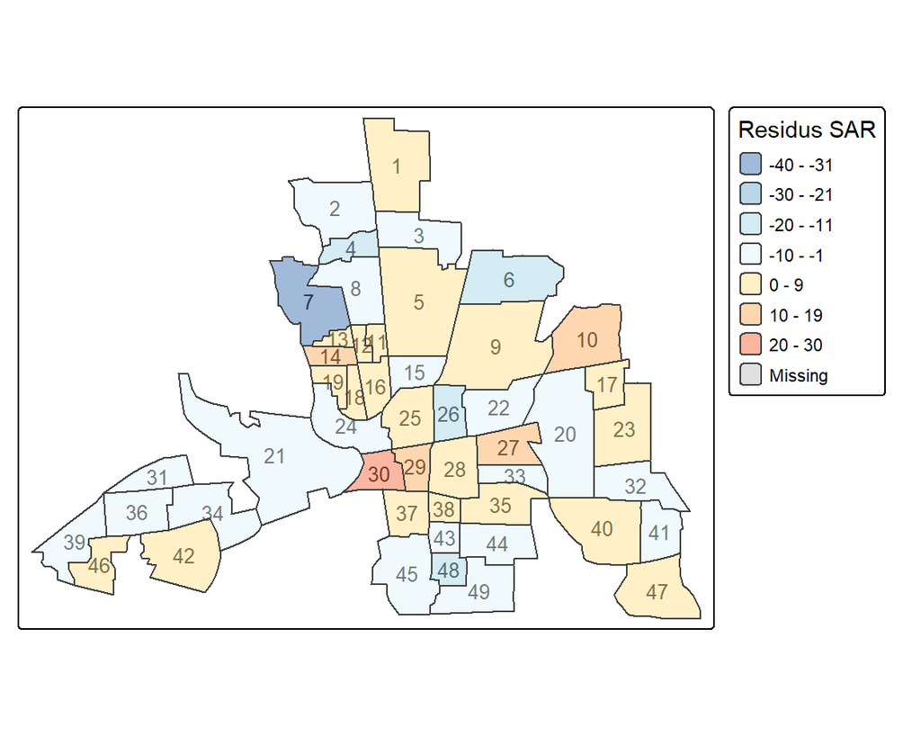

```r
columbus$sar_res<-resid(CRIME_SAR)

tm_shape(columbus) +tm_text(text = "POLYID",size=0.8)+
  tm_polygons("sar_res", alpha=0.5,palette="-RdYlBu",
              style="pretty", id="POLYID",
              title="Residus SAR")
```

- Représentation de la densité des résidus MCO, SLX et SAR

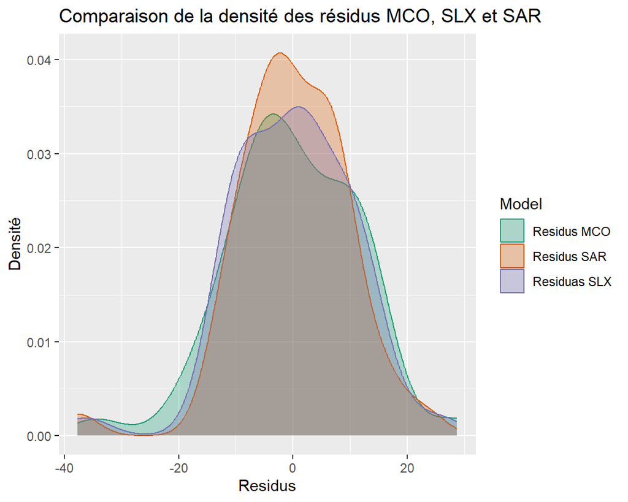

```r
columbus%>%st_drop_geometry() %>%
  pivot_longer(cols = c('ols_res','slx_res','sar_res')) %>%
  ggplot() +
    geom_density(mapping = aes(x = value,
                          color = name, fill = name),
            alpha = 0.3) + #stop code here first time to know the order of the labels
    scale_color_manual(values=brewer.pal(n = 3, name = "Dark2"),labels=c("Residus MCO","Residus SAR","Residuas SLX"))+
    scale_fill_manual(values=brewer.pal(n = 3, name = "Dark2"),labels=c("Residus MCO","Residus SAR","Residuas SLX")) +
    labs(x = "Residus", y = "Densité",
       title = "Comparaison de la densité des résidus MCO, SLX et SAR",
       color = "Model",
       fill = "Model")
```

- Prédictions avec le modèle SAR

  a. Prédiction selon les 3 prédicteurs, Trend Corrected, Trend Signal Noise et BLUP

```r
columbus$pred_TC <- as.numeric(predict(CRIME_SAR,  listw=col.listw, pred.type = "TC"))
#The Trend Signal Noise Predictor
columbus$pred_TS <- as.numeric(predict(CRIME_SAR,  listw=col.listw, pred.type = "TS"))
columbus$pred_BP <- as.numeric(predict(CRIME_SAR,  listw=col.listw, pred.type = "BP"))

summary(columbus[,c('pred_TC','pred_TS','pred_BP')]%>%st_drop_geometry())
```

```
    pred_TC          pred_TS         pred_BP
 Min.   : 3.112   Min.   : 5.11   Min.   : 8.12
 1st Qu.:27.425   1st Qu.:24.22   1st Qu.:22.64
 Median :36.929   Median :38.16   Median :38.32
 Mean   :35.074   Mean   :35.13   Mean   :35.12
 3rd Qu.:43.098   3rd Qu.:44.93   3rd Qu.:46.12
 Max.   :52.804   Max.   :54.77   Max.   :58.17
```

2. Comparaison des prédictions

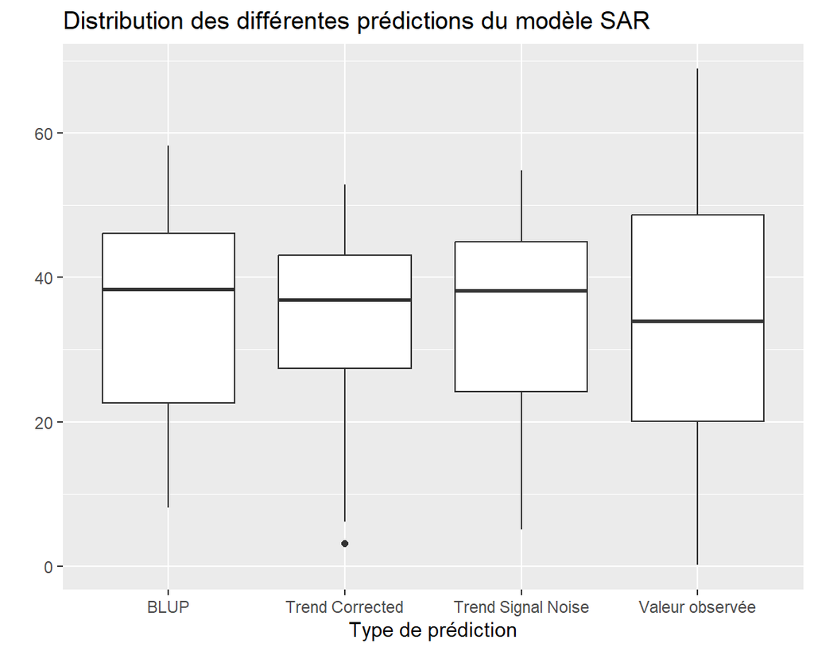

```r
columbus %>%
  ggplot() +
  geom_boxplot(aes(x = "Trend Corrected", y = pred_TC)) +
  geom_boxplot(aes(x = "Trend Signal Noise", y = pred_TS)) +
  geom_boxplot(aes(x = "BLUP", y = pred_BP)) +
    geom_boxplot(aes(x = "Valeur observée", y = CRIME))+
  xlab("Type de prédiction") +
  ylab("") +
  ggtitle("Distribution des différentes prédictions du modèle SAR")
```

3. Représentation de la densité des prédictions avec la fonction **geom_density**

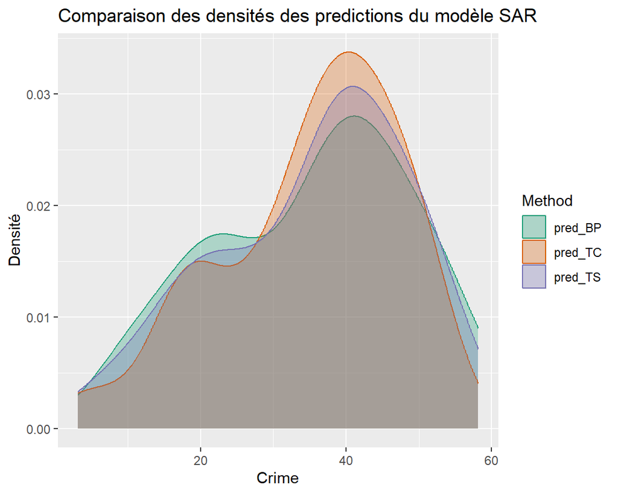

```r
columbus%>%st_drop_geometry() %>%
  pivot_longer(cols = c('pred_TC','pred_TS','pred_BP')) %>%
  ggplot() +
    geom_density(mapping = aes(x = value,
                          color = name, fill = name),
            alpha = 0.3) +
    scale_color_manual(values=brewer.pal(n = 3, name = "Dark2"))+
    scale_fill_manual(values=brewer.pal(n = 3, name = "Dark2")) +
    labs(x = "Crime", y = "Densité",
       title = "Comparaison des densités des predictions du modèle SAR",
       color = "Method",
       fill = "Method")
```

4. Représentation de la densité des prédictions avec la fonction **geom_density_ridges**

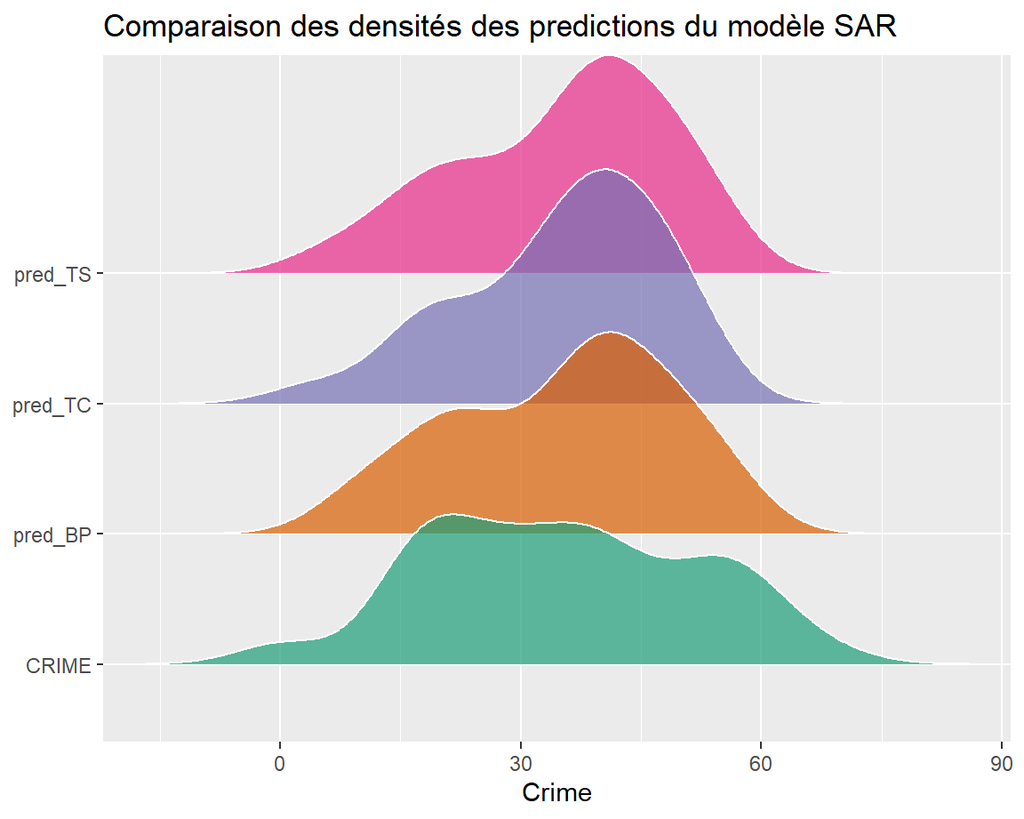

```r
columbus%>%st_drop_geometry() %>%
  pivot_longer(cols = c('pred_TC','pred_TS','pred_BP','CRIME')) %>%
  ggplot() +
  geom_density_ridges(mapping = aes(x = value,
                                    y = name,
                                    fill = name),
                      color = "white",alpha=0.7)+
  scale_fill_manual(values = alpha(brewer.pal(n = 4, name = "Dark2"), 0.7))+
  guides(color = "none",fill="none") +
  labs(x = "Crime", y = NULL, title = "Comparaison des densités des predictions du modèle SAR",fill = "Method")
```

### 4.4 Estimation du modèle SAR et variables instrumentales

- Estimation avec la fonction **stsls**

```r
CRIME_2SLS<-stsls(CRIME~INC+HOVAL, listw=col.listw,  data=columbus)
summary(CRIME_2SLS)
```

```
Call:stsls(formula = CRIME ~ INC + HOVAL, data = columbus, listw = col.listw)

Residuals:
      Min        1Q    Median        3Q       Max
-37.94358  -5.64216  -0.24203   6.22748  22.82069

Coefficients:
             Estimate Std. Error t value  Pr(>|t|)
Rho          0.461487   0.187939  2.4555  0.014069
(Intercept) 43.528473  11.061569  3.9351 8.316e-05
INC         -0.999276   0.385591 -2.5915  0.009555
HOVAL       -0.265650   0.092391 -2.8753  0.004037

Residual variance (sigma squared): 104.66, (sigma: 10.231)
Anselin-Kelejian (1997) test for residual autocorrelation
test value: 0.01708, p-value: 0.89602
```

- Calcul des effets directs et indirects

```r
 set.seed(132)
summary(impacts(CRIME_2SLS,listw=col.listw, R=1000), zstats=TRUE)
```

```
Impact measures (lag, exact):
                Direct   Indirect      Total
INC dy/dx   -1.0605410 -0.7950776 -1.8556186
HOVAL dy/dx -0.2819369 -0.2113655 -0.4933024
========================================================
Simulation results ( variance matrix):
Direct:

Iterations = 1:996
Thinning interval = 1
Number of chains = 1
Sample size per chain = 996

1. Empirical mean and standard deviation for each variable,
   plus standard error of the mean:

               Mean     SD Naive SE Time-series SE
INC dy/dx   -1.0656 0.3855 0.012216       0.011082
HOVAL dy/dx -0.2932 0.1110 0.003517       0.003517

2. Quantiles for each variable:

               2.5%     25%     50%     75%    97.5%
INC dy/dx   -1.7994 -1.3350 -1.0685 -0.8088 -0.29175
HOVAL dy/dx -0.5059 -0.3651 -0.2916 -0.2236 -0.07339

========================================================
Indirect:

Iterations = 1:996
Thinning interval = 1
Number of chains = 1
Sample size per chain = 996

1. Empirical mean and standard deviation for each variable,
   plus standard error of the mean:

               Mean     SD Naive SE Time-series SE
INC dy/dx   -0.8912 0.8949  0.02836        0.03723
HOVAL dy/dx -0.3114 0.4645  0.01472        0.01472
```

[output cut: 28 more lines]

```
========================================================
Simulated standard errors
               Direct  Indirect     Total
INC dy/dx   0.3855454 0.8949114 1.0120725
HOVAL dy/dx 0.1109953 0.4645255 0.5265678

Simulated z-values:
               Direct   Indirect     Total
INC dy/dx   -2.763849 -0.9958297 -1.933427
HOVAL dy/dx -2.641897 -0.6703020 -1.148210

Simulated p-values:
            Direct    Indirect Total
INC dy/dx   0.0057124 0.31933  0.053184
HOVAL dy/dx 0.0082443 0.50267  0.250882
```

- Analyse des résidus

  a. Cartographie des résidus

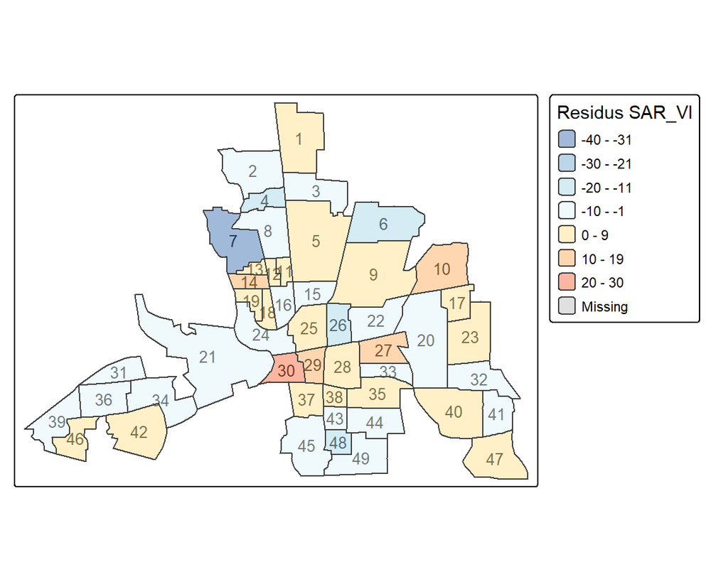

```r
columbus$sar_2sls_res<-resid(CRIME_2SLS)
#Maps
tm_shape(columbus) +tm_text(text = "POLYID",size=0.8)+
  tm_polygons("sar_2sls_res", alpha=0.5,palette="-RdYlBu",
              style="pretty", id="POLYID",
              title="Residus SAR_VI")
```

2. Comparaison des densités des résidus MCO, SAR et SAR_VI

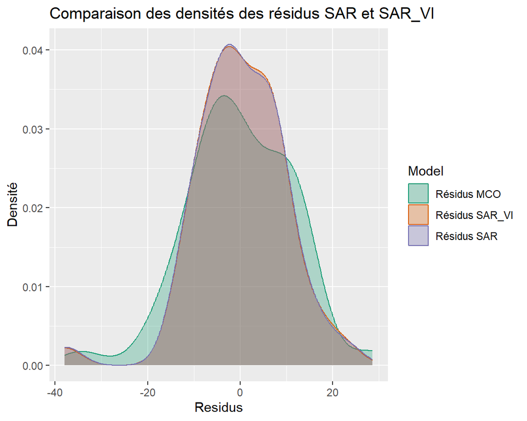

```r
columbus%>%st_drop_geometry() %>%
  pivot_longer(cols = c('ols_res','sar_res','sar_2sls_res')) %>%
  ggplot() +
    geom_density(mapping = aes(x = value,
                          color = name, fill = name),
            alpha = 0.3) + #stop code here first time to know the order of the labels
    scale_color_manual(values=brewer.pal(n = 3, name = "Dark2"),labels=c("Résidus MCO","Résidus SAR_VI","Résidus SAR"))+
    scale_fill_manual(values=brewer.pal(n = 3, name = "Dark2"),labels=c("Résidus MCO","Résidus SAR_VI","Résidus SAR")) +
    labs(x = "Residus", y = "Densité",
       title = "Comparaison des densités des résidus SAR et SAR_VI",
       color = "Model",
       fill = "Model")
```

## 5 Estimation du modèle SEM

### 5.1 Estimation avec la fonction **errorsarlm**

```r
CRIME_SEM= errorsarlm(CRIME~INC+HOVAL, listw=col.listw,  data=columbus)
#where lambda is found by optimize() first,  and other parameters by generalized least squares subsequently.
summary(CRIME_SEM)
```

```
Call:
errorsarlm(formula = CRIME ~ INC + HOVAL, data = columbus, listw = col.listw)

Residuals:
      Min        1Q    Median        3Q       Max
-34.65998  -6.16943  -0.70623   7.75392  23.43878

Type: error
Coefficients: (asymptotic standard errors)
             Estimate Std. Error z value  Pr(>|z|)
(Intercept) 60.279470   5.365594 11.2344 < 2.2e-16
INC         -0.957305   0.334231 -2.8642 0.0041806
HOVAL       -0.304559   0.092047 -3.3087 0.0009372

Lambda: 0.54675, LR test value: 7.2556, p-value: 0.0070679
Asymptotic standard error: 0.13805
    z-value: 3.9605, p-value: 7.4786e-05
Wald statistic: 15.686, p-value: 7.4786e-05

Log likelihood: -183.7494 for error model
ML residual variance (sigma squared): 97.674, (sigma: 9.883)
Number of observations: 49
Number of parameters estimated: 5
AIC: 377.5, (AIC for lm: 382.75)
```

### 5.2 Analyse des résidus

- Représentation cartographique des résidus

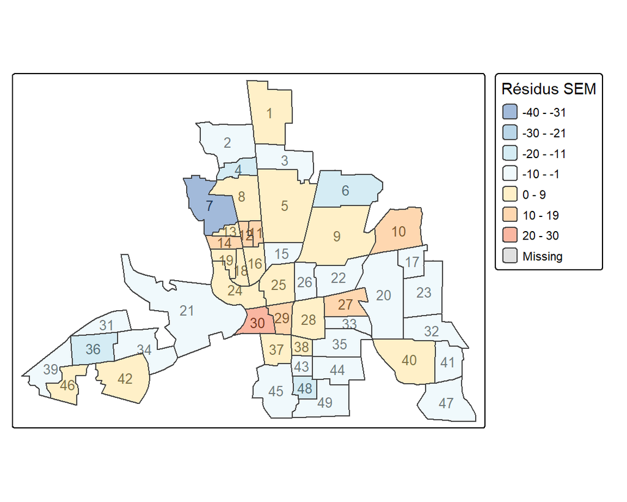

```r
columbus$sem_res<-resid(CRIME_SEM)
#Maps
tm_shape(columbus) +tm_text(text = "POLYID",size=0.8)+
  tm_polygons("sem_res", alpha=0.5,palette="-RdYlBu",
              style="pretty", id="POLYID",
              title="Résidus SEM")
```

- Comparaison des densités des résidus des différents modèles

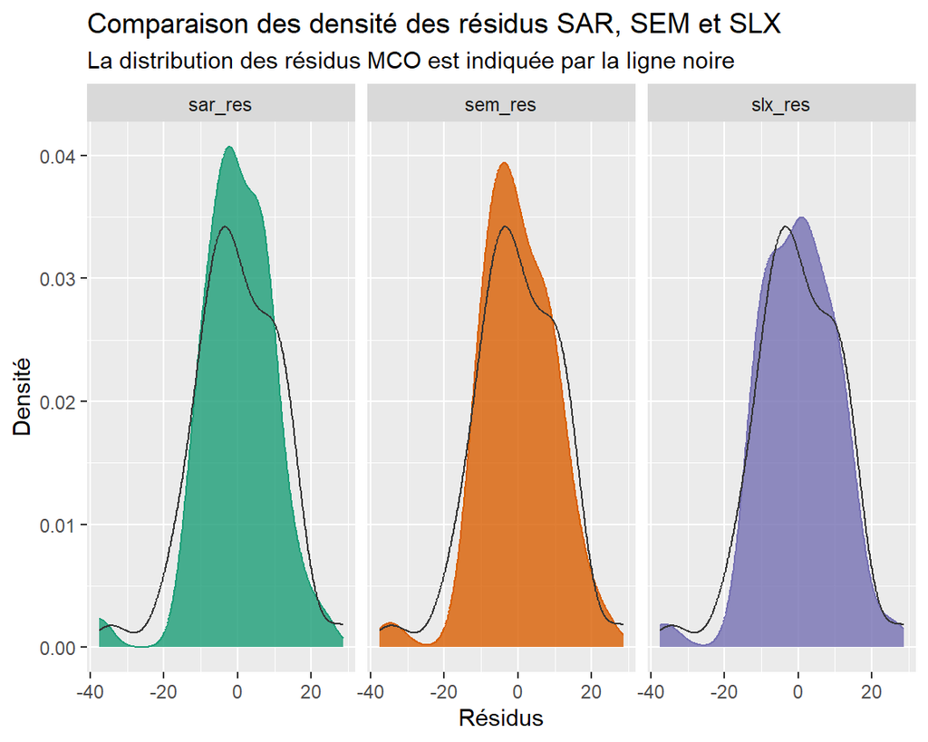

```r
columbus%>%st_drop_geometry() %>%
  pivot_longer(cols = c('slx_res','sar_res','sem_res',)) %>%
  ggplot() +
  geom_density(mapping = aes(x = value,
                          color = name, fill = name),
            size = 0.5)+
  geom_density(mapping = aes(x = ols_res),
                color = "gray20", size = 0.5) +
  scale_fill_manual(values = alpha(brewer.pal(n = 4, name = "Dark2"), 0.8)) +
  scale_color_manual(values = alpha(brewer.pal(n = 4, name = "Dark2"), 1)) +
  guides(color = "none", fill = "none") +
  labs(x = "Résidus", y = "Densité",
       title = "Comparaison des densité des résidus SAR, SEM et SLX",
       subtitle = "La distribution des résidus MCO est indiquée par la ligne noire")+   facet_wrap(~ name, nrow = 1)
```

## 6 Estimation du modèle SDM

### 6.1 Estimation avec la fonction **lagsarlm**

```r
CRIME_SDM <- lagsarlm(CRIME~INC+HOVAL, listw=col.listw,  data=columbus, Durbin = TRUE)
summary(CRIME_SDM)
```

```
Call:
lagsarlm(formula = CRIME ~ INC + HOVAL, data = columbus, listw = col.listw,
    Durbin = TRUE)

Residuals:
      Min        1Q    Median        3Q       Max
-37.31199  -6.49556  -0.22971   6.17872  22.74795

Type: mixed
Coefficients: (asymptotic standard errors)
             Estimate Std. Error z value  Pr(>|z|)
(Intercept) 44.320003  13.045474  3.3973 0.0006804
INC         -0.919906   0.334742 -2.7481 0.0059941
HOVAL       -0.297129   0.090416 -3.2863 0.0010153
lag.INC     -0.583913   0.574224 -1.0169 0.3092140
lag.HOVAL    0.257684   0.187235  1.3763 0.1687404

Rho: 0.40346, LR test value: 4.6627, p-value: 0.030825
Asymptotic standard error: 0.16133
    z-value: 2.5008, p-value: 0.012392
Wald statistic: 6.254, p-value: 0.012392

Log likelihood: -181.6393 for mixed model
ML residual variance (sigma squared): 93.272, (sigma: 9.6578)
Number of observations: 49
Number of parameters estimated: 7
AIC: 377.28, (AIC for lm: 379.94)
LM test for residual autocorrelation
test value: 0.36258, p-value: 0.54708
```

### 6.2 Calcul des effets directs et indirects

```r
set.seed(135)
summary(impacts(CRIME_SDM,listw=col.listw, R=1000), zstats=TRUE)
```

```
Impact measures (mixed, exact):
                Direct  Indirect       Total
INC dy/dx   -1.0249878 -1.495926 -2.52091388
HOVAL dy/dx -0.2819673  0.215844 -0.06612334
========================================================
Simulation results ( variance matrix):
Direct:

Iterations = 1:1000
Thinning interval = 1
Number of chains = 1
Sample size per chain = 1000

1. Empirical mean and standard deviation for each variable,
   plus standard error of the mean:

               Mean      SD Naive SE Time-series SE
INC dy/dx   -1.0296 0.32680 0.010334       0.010334
HOVAL dy/dx -0.2834 0.09621 0.003042       0.003042

2. Quantiles for each variable:

               2.5%     25%     50%     75%    97.5%
INC dy/dx   -1.6434 -1.2655 -1.0429 -0.8140 -0.36921
HOVAL dy/dx -0.4691 -0.3472 -0.2858 -0.2187 -0.09778

========================================================
Indirect:

Iterations = 1:1000
Thinning interval = 1
Number of chains = 1
Sample size per chain = 1000

1. Empirical mean and standard deviation for each variable,
   plus standard error of the mean:

               Mean     SD Naive SE Time-series SE
INC dy/dx   -1.5127 0.8109  0.02564        0.02564
HOVAL dy/dx  0.2192 0.3478  0.01100        0.01100
```

[output cut: 28 more lines]

```
========================================================
Simulated standard errors
                Direct  Indirect     Total
INC dy/dx   0.32680280 0.8109480 0.8725374
HOVAL dy/dx 0.09620997 0.3478071 0.3866546

Simulated z-values:
               Direct   Indirect      Total
INC dy/dx   -3.150430 -1.8653535 -2.9136565
HOVAL dy/dx -2.945887  0.6301561 -0.1661714

Simulated p-values:
            Direct    Indirect Total
INC dy/dx   0.0016303 0.062132 0.0035722
HOVAL dy/dx 0.0032203 0.528592 0.8680221
```

### 6.3 Analyse des résidus

- Cartographie des résidus

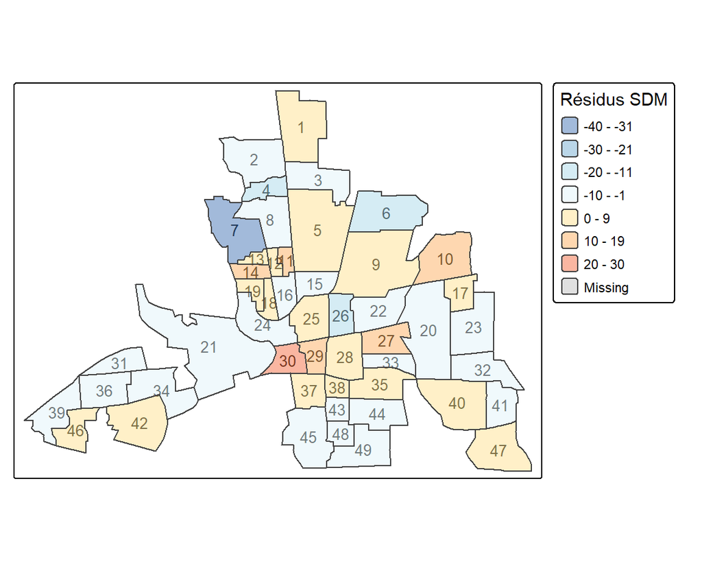

```r
columbus$sdm_res<-resid(CRIME_SDM)
#Maps
tm_shape(columbus) +tm_text(text = "POLYID",size=0.8)+
  tm_polygons("sdm_res", alpha=0.5,palette="-RdYlBu",
              style="pretty", id="POLYID",
              title="Résidus SDM")
```

- Représentation de la distribution des résidus

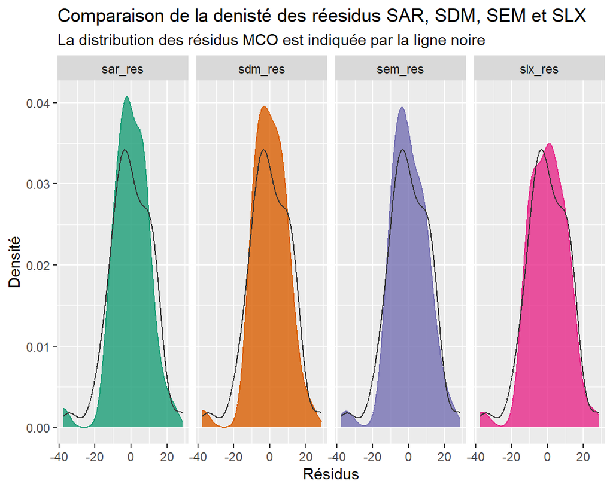

```r
columbus%>%st_drop_geometry() %>%
  pivot_longer(cols = c('slx_res','sar_res','sem_res','sdm_res')) %>%
  ggplot() +
  geom_density(mapping = aes(x = value,
                          color = name, fill = name),
            size = 0.5) +
  geom_density(mapping = aes(x = ols_res),
                color = "gray20", size = 0.5) +
  scale_fill_manual(values = alpha(brewer.pal(n = 4, name = "Dark2"), 0.8)) +
  scale_color_manual(values = alpha(brewer.pal(n = 4, name = "Dark2"), 1)) +
  guides(color = "none", fill = "none") +
  labs(x = "Résidus", y = "Densité",
       title = "Comparaison de la denisté des réesidus SAR, SDM, SEM et SLX",
       subtitle = "La distribution des résidus MCO est indiquée par la ligne noire") +
  facet_wrap(~ name, nrow = 1)
```

### 6.4 Prédictions avec le modèle SDM

- Prédiction selon les 3 prédicteurs, Trend Corrected, Trend Signal Noise et BLUP

```r
columbus$pred_sdm_TC <- as.numeric(predict(CRIME_SDM,  listw=col.listw, pred.type = "TC"))
#The Trend Signal Noise Predictor
columbus$pred_sdm_TS <- as.numeric(predict(CRIME_SDM,  listw=col.listw, pred.type = "TS"))
columbus$pred_sdm_BP <- as.numeric(predict(CRIME_SDM,  listw=col.listw, pred.type = "BP"))
summary(columbus[,c('pred_sdm_TC','pred_sdm_TS','pred_sdm_BP')]%>%st_drop_geometry())
```

```
  pred_sdm_TC      pred_sdm_TS      pred_sdm_BP
 Min.   : 5.979   Min.   : 6.837   Min.   : 8.704
 1st Qu.:29.185   1st Qu.:25.815   1st Qu.:23.648
 Median :37.106   Median :37.840   Median :38.276
 Mean   :35.120   Mean   :35.129   Mean   :35.110
 3rd Qu.:45.240   3rd Qu.:44.735   3rd Qu.:46.147
 Max.   :52.688   Max.   :54.889   Max.   :57.988
```

- Comparaison des prédictions

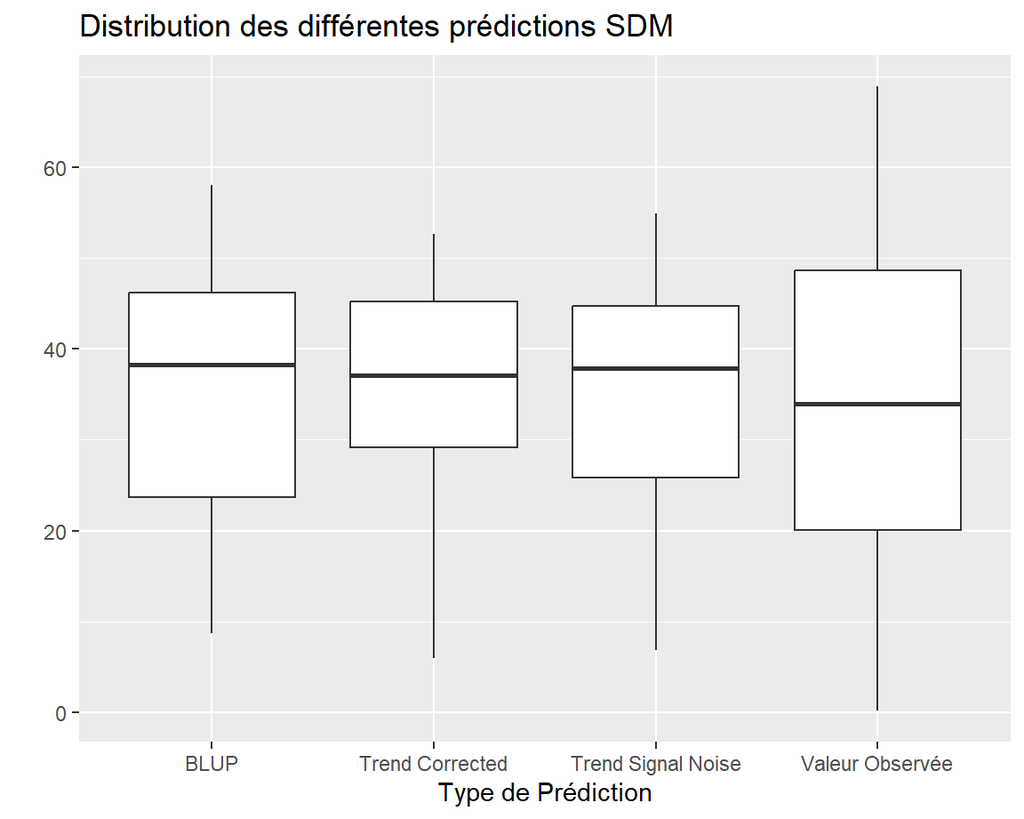

```r
columbus %>%
  ggplot() +
  geom_boxplot(aes(x = "Trend Corrected", y = pred_sdm_TC)) +
  geom_boxplot(aes(x = "Trend Signal Noise", y = pred_sdm_TS)) +
  geom_boxplot(aes(x = "BLUP", y = pred_sdm_BP)) +
  geom_boxplot(aes(x = "Valeur Observée", y = CRIME))+
  xlab("Type de Prédiction") +
  ylab("") +
  ggtitle("Distribution des différentes prédictions SDM")
```

- Comparaison des densités des prédictions du modèle SDM

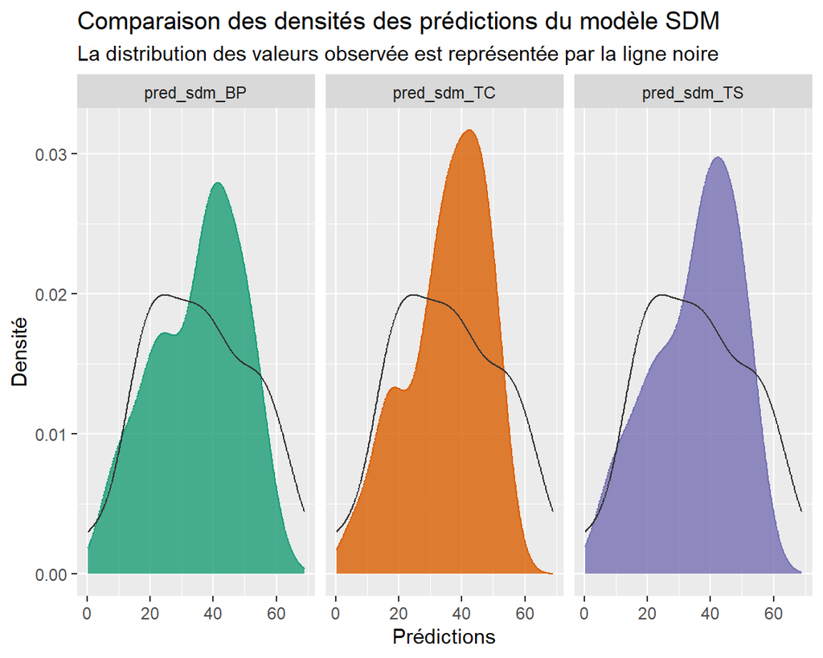

```r
columbus%>%st_drop_geometry() %>%
   pivot_longer(cols = c('pred_sdm_TC','pred_sdm_TS','pred_sdm_BP')) %>%
  ggplot() +
  geom_density(mapping = aes(x = value,
                          color = name, fill = name),
            size = 0.5) +
  geom_density(mapping = aes(x = CRIME),
                color = "gray20", size = 0.5) +
  scale_fill_manual(values = alpha(brewer.pal(n = 3, name = "Dark2"), 0.8)) +
  scale_color_manual(values = alpha(brewer.pal(n = 3, name = "Dark2"), 1)) +
  guides(color = "none", fill = "none") +
  labs(x = "Prédictions", y = "Densité",
       title = "Comparaison des densités des prédictions du modèle SDM",
       subtitle = "La distribution des valeurs observée est représentée par la ligne noire") +
  facet_wrap(~ name, nrow = 1)
```

## 7 Synthèse des résultats

```r
stargazer(CRIME_OLS,CRIME_SLX, CRIME_SAR,CRIME_SEM,CRIME_SDM, type = "text",header=FALSE,model.names = FALSE,
          dep.var.labels.include = FALSE,column.labels =  c("OLS","SLX","SAR","SEM","SDM"),
          model.numbers          = FALSE,  title="Résultats d'estimation des modèles spatiaux")
```

```
Résultats d'estimation des modèles spatiaux
===============================================================================================
                                                Dependent variable:
                    ---------------------------------------------------------------------------
                             OLS                    SLX              SAR       SEM       SDM
-----------------------------------------------------------------------------------------------
INC                       -1.597***              -1.097***        -1.049*** -0.957*** -0.920***
                           (0.334)                (0.374)          (0.307)   (0.334)   (0.335)

HOVAL                      -0.274**              -0.294***        -0.266*** -0.305*** -0.297***
                           (0.103)                (0.102)          (0.089)   (0.092)   (0.090)

lag.INC                                           -1.399**                             -0.584
                                                  (0.560)                              (0.574)

lag.HOVAL                                          0.215                                0.258
                                                  (0.208)                              (0.187)

Constant                  68.619***              74.553***        45.603*** 60.279*** 44.320***
                           (4.735)                (6.716)          (7.257)   (5.366)  (13.045)

-----------------------------------------------------------------------------------------------
Observations                  49                     49              49        49        49
R2                          0.552                  0.611
Adjusted R2                 0.533                  0.575
Log Likelihood                                                    -182.674  -183.749  -181.639
sigma2                                                             96.857    97.674    93.272
Akaike Inf. Crit.                                                  375.348   377.499   377.279
Residual Std. Error    11.435 (df = 46)       10.907 (df = 44)
F Statistic         28.386*** (df = 2; 46) 17.242*** (df = 4; 44)
Wald Test (df = 1)                                                12.547*** 15.686***  6.254**
LR Test (df = 1)                                                  9.407***  7.256***   4.663**
===============================================================================================
Note:                                                               *p<0.1; **p<0.05; ***p<0.01
```

## 8 Procédures de choix du modèle

### 8.1 Stratégie de Lesage et Pace

- On commence par la branche de gauche ie SDM/SAR

  $H_0 : \theta = 0$

  Le modèle non contraint est le modèle SDM et le modèle contraint le modèle SAR

```r
sdm_vs_sar<-LR.Sarlm(CRIME_SDM,CRIME_SAR)
print(sdm_vs_sar)
```

```
    Likelihood ratio for spatial linear models

data:
Likelihood ratio = 2.0694, df = 2, p-value = 0.3553
sample estimates:
Log likelihood of CRIME_SDM Log likelihood of CRIME_SAR
                  -181.6393                   -182.6740
```

On accepte l’hypothèse nulle p-value est > 5% et donc on part sur le modèle SAR et on teste le modèle SAR/OLS.

```r
sar_vs_ols<-LR.Sarlm(CRIME_SAR,CRIME_OLS)
print(sar_vs_ols)
```

```
    Likelihood ratio for spatial linear models

data:
Likelihood ratio = 9.4065, df = 1, p-value = 0.002162
sample estimates:
Log likelihood of CRIME_SAR Log likelihood of CRIME_OLS
                  -182.6740                   -187.3772
```

la p-value <5%, on rejette donc l’hypothèse H0 et choisit un modèle SAR

- Sur la branche du centre on teste SDM/SLX

  $H_0 : \rho=0, \theta \neq 0, \theta + \rho*\beta \neq 0$

  Le modèle non contraint est le modèle SDM et le modèle contraint le modèle SLX

```r
sdm_vs_slx<-LR.Sarlm(CRIME_SDM,CRIME_SLX)
print(sdm_vs_slx)
```

```
    Likelihood ratio for spatial linear models

data:
Likelihood ratio = 4.6627, df = 1, p-value = 0.03082
sample estimates:
Log likelihood of CRIME_SDM Log likelihood of CRIME_SLX
                  -181.6393                   -183.9706
```

la p-value <5%, on rejette donc l’hypothèse H0 et choisit un modèle SDM

  $H_0 : \theta + \rho*\beta \neq 0$

  Le modèle non contraint est le modèle SDM et le modèle contraint le modèle SEM

```r
sdm_vs_sem<-LR.Sarlm(CRIME_SDM,CRIME_SEM)
print(sdm_vs_sem)
```

```
    Likelihood ratio for spatial linear models

data:
Likelihood ratio = 4.2203, df = 2, p-value = 0.1212
sample estimates:
Log likelihood of CRIME_SDM Log likelihood of CRIME_SEM
                  -181.6393                   -183.7494
```

la p-value > 5% le modèle retenu est le modèle SEM. On continue alos sur la branche et teste SEM/OLS

```r
sem_vs_ols<-LR.Sarlm(CRIME_SEM,CRIME_OLS)
print(sem_vs_ols)
```

```
    Likelihood ratio for spatial linear models

data:
Likelihood ratio = 7.2556, df = 1, p-value = 0.007068
sample estimates:
Log likelihood of CRIME_SEM Log likelihood of CRIME_OLS
                  -183.7494                   -187.3772
```

la p-value < 5% on rejette l’hypothèse nulle et retient le modèle SEM.

La stratégie de test retient ainsi 2 modèles, le modèle SAR et le modèle SEM. On peut reteinir le modèle SAR qui a une p-value plus “concluante” (0.356 vs 0.12 pour le premier niveau, 0.002 vs 0.007 pour le second niveau).

### 8.2 La stratégie de Elhorst

- Premier niveau

  Branche de droite : Test LM-error $\lambda=0$

```r
lm.LMtests(CRIME_OLS,listw = col.listw,test="LMerr")
```

```
    Rao's score (a.k.a Lagrange multiplier) diagnostics for spatial
    dependence

data:
model: lm(formula = CRIME ~ INC + HOVAL, data = columbus)
test weights: listw

RSerr = 5.2062, df = 1, p-value = 0.02251
```

la p-value<5% on rejette l’hypothèse nulle et $\lambda \neq 0$, on applique le Test LM_lag: $\rho=0$

```r
lm.LMtests(CRIME_OLS,listw = col.listw,test="LMlag")
```

```
    Rao's score (a.k.a Lagrange multiplier) diagnostics for spatial
    dependence

data:
model: lm(formula = CRIME ~ INC + HOVAL, data = columbus)
test weights: listw

RSlag = 8.898, df = 1, p-value = 0.002855
```

la p-value<5% on rejette l’hypothèse nulle et $\rho \neq 0$.

**Tests robustes :**

- RLMerr examines the spatially autocorrelated residuals in the possible presence of an omitted lagged dependent variable

- RLMlag examines the spatially lagged dependent variablesin the possible presence of omitted spatially autocorrelated residuals

```r
lm.LMtests(CRIME_OLS,listw = col.listw,test="RLMerr")
```

```
    Rao's score (a.k.a Lagrange multiplier) diagnostics for spatial
    dependence

data:
model: lm(formula = CRIME ~ INC + HOVAL, data = columbus)
test weights: listw

adjRSerr = 0.043906, df = 1, p-value = 0.834
```

la p-value >5% et donc $\lambda=0$

```r
lm.LMtests(CRIME_OLS,listw = col.listw,test="RLMlag")
```

```
    Rao's score (a.k.a Lagrange multiplier) diagnostics for spatial
    dependence

data:
model: lm(formula = CRIME ~ INC + HOVAL, data = columbus)
test weights: listw

adjRSlag = 3.7357, df = 1, p-value = 0.05326
```

- Second niveau

Sur la branche de gauche, si $\rho \neq 0$ et $\lambda=0$, on teste $H_0 : \theta = 0$

```r
sdm_vs_sar<-LR.Sarlm(CRIME_SDM,CRIME_SAR)
print(sdm_vs_sar)
```

```
    Likelihood ratio for spatial linear models

data:
Likelihood ratio = 2.0694, df = 2, p-value = 0.3553
sample estimates:
Log likelihood of CRIME_SDM Log likelihood of CRIME_SAR
                  -181.6393                   -182.6740
```

la p-value >5% on ne rejette pas $H_0 : \theta = 0$ et on retient le modèle SAR.

On peut aussi comparer les AIC des différents modèles.

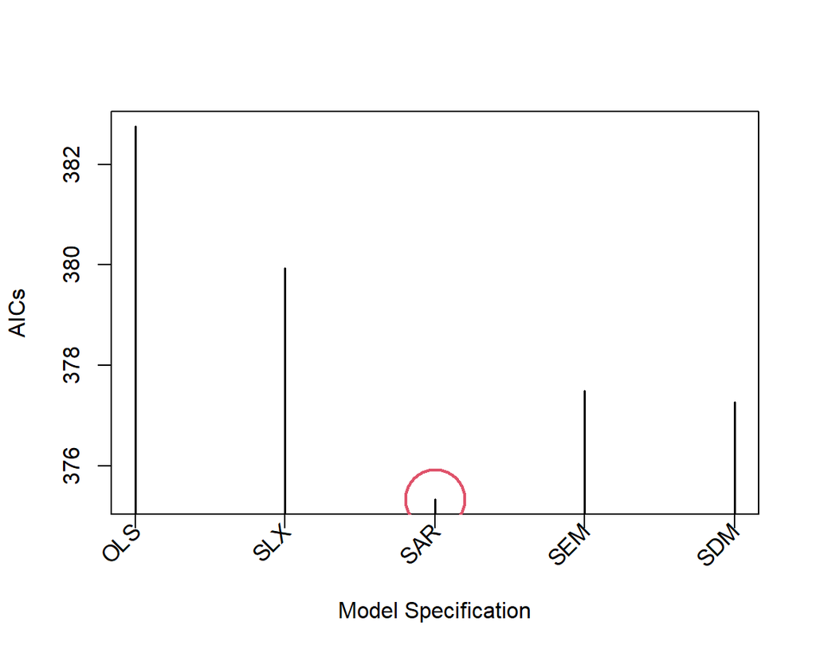

```r
AICs<-c(AIC(CRIME_OLS),AIC(CRIME_SLX),AIC(CRIME_SAR), AIC(CRIME_SEM), AIC(CRIME_SDM))
plot(AICs, type="h", lwd=1.5, xaxt="n", xlab="")
axis(1, at=1:5,labels=F) #5= number of models
labels<-c("OLS", "SLX","SAR", "SEM","SDM")
text(1:5, par("usr")[3]-.25, srt=45, adj=1, labels=labels, xpd=T)
mtext(side=1, text="Model Specification", line=3)
symbols(x= which.min(AICs), y=AICs[which.min(AICs)],inches = FALSE, circles=0.2, fg=2,lwd=2,add=T)
```

les BIC

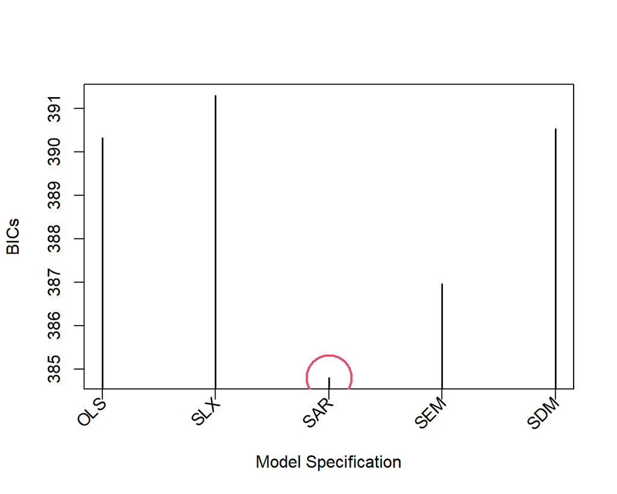

```r
BICs<-c(BIC(CRIME_OLS),BIC(CRIME_SLX),BIC(CRIME_SAR), BIC(CRIME_SEM), BIC(CRIME_SDM))
plot(BICs, type="h", lwd=1.5, xaxt="n", xlab="")
axis(1, at=1:5,labels=F) #5= number of models
labels<-c("OLS", "SLX","SAR", "SEM","SDM")
text(1:5, par("usr")[3]-.25, srt=45, adj=1, labels=labels, xpd=T)
mtext(side=1, text="Model Specification", line=3)
symbols(x= which.min(BICs), y=BICs[which.min(BICs)],inches = FALSE, circles=0.2, fg=2,lwd=2,add=T)
```

ou encore la valeur de la vraisemblance qui doit être maximisée

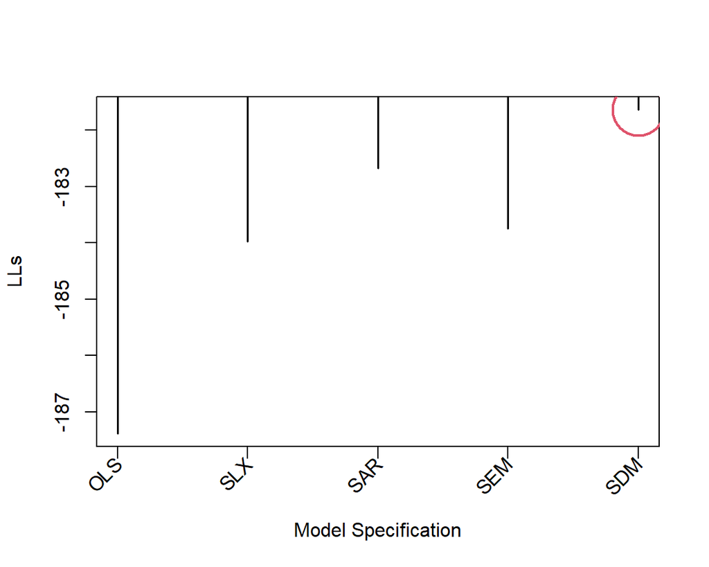

```r
LLs<-c(logLik(CRIME_OLS),logLik(CRIME_SLX),logLik(CRIME_SAR), logLik(CRIME_SEM), logLik(CRIME_SDM))
plot(LLs, type="h", lwd=1.5, xaxt="n", xlab="")
axis(1, at=1:5,labels=F) #5= number of models
labels<-c("OLS", "SLX","SAR", "SEM","SDM")
text(1:5, par("usr")[3]-.25, srt=45, adj=1, labels=labels, xpd=T)
mtext(side=1, text="Model Specification", line=3)
symbols(x= which.max(LLs), y=LLs[which.max(LLs)],inches = FALSE, circles=0.2, fg=2,lwd=2,add=T)
```